# Risk Factor Analysis

## Outcome Variable

**Outcome Variable:** stunted

## Predictor Variables

**Intervention Variable:** gagebrth

**Adjustment Set:**

- arm
- sex
- W_mage
- meducyrs
- feducyrs
- hhwealth_quart
- W_nrooms
- brthmon
- W_parity
- impsan
- delta_W_mage
- delta_meducyrs
- delta_feducyrs
- delta_hhwealth_quart
- delta_W_nrooms
- delta_brthmon
- delta_W_parity
- delta_impsan

## Stratifying Variables

The analysis was stratified on these variable(s):

- agecat
- studyid
- country

## Data Summary

| agecat | studyid | country | gagebrth | stunted | n_cell | n |
| --- | --- | --- | --- | --- | --- | --- |
| Birth | CMC-V-BCS-2002 | INDIA | Full or late term | 0 | 48 | 92 |
| Birth | CMC-V-BCS-2002 | INDIA | Full or late term | 1 | 10 | 92 |
| Birth | CMC-V-BCS-2002 | INDIA | Preterm | 0 | 8 | 92 |
| Birth | CMC-V-BCS-2002 | INDIA | Preterm | 1 | 3 | 92 |
| Birth | CMC-V-BCS-2002 | INDIA | Early term | 0 | 19 | 92 |
| Birth | CMC-V-BCS-2002 | INDIA | Early term | 1 | 4 | 92 |
| Birth | COHORTS | GUATEMALA | Full or late term | 0 | 330 | 617 |
| Birth | COHORTS | GUATEMALA | Full or late term | 1 | 11 | 617 |
| Birth | COHORTS | GUATEMALA | Preterm | 0 | 82 | 617 |
| Birth | COHORTS | GUATEMALA | Preterm | 1 | 13 | 617 |
| Birth | COHORTS | GUATEMALA | Early term | 0 | 170 | 617 |
| Birth | COHORTS | GUATEMALA | Early term | 1 | 11 | 617 |
| Birth | COHORTS | INDIA | Full or late term | 0 | 536 | 1293 |
| Birth | COHORTS | INDIA | Full or late term | 1 | 34 | 1293 |
| Birth | COHORTS | INDIA | Preterm | 0 | 242 | 1293 |
| Birth | COHORTS | INDIA | Preterm | 1 | 43 | 1293 |
| Birth | COHORTS | INDIA | Early term | 0 | 391 | 1293 |
| Birth | COHORTS | INDIA | Early term | 1 | 47 | 1293 |
| Birth | COHORTS | PHILIPPINES | Full or late term | 0 | 1128 | 3024 |
| Birth | COHORTS | PHILIPPINES | Full or late term | 1 | 36 | 3024 |
| Birth | COHORTS | PHILIPPINES | Preterm | 0 | 561 | 3024 |
| Birth | COHORTS | PHILIPPINES | Preterm | 1 | 88 | 3024 |
| Birth | COHORTS | PHILIPPINES | Early term | 0 | 1150 | 3024 |
| Birth | COHORTS | PHILIPPINES | Early term | 1 | 61 | 3024 |
| Birth | IRC | INDIA | Full or late term | 0 | 211 | 369 |
| Birth | IRC | INDIA | Full or late term | 1 | 27 | 369 |
| Birth | IRC | INDIA | Preterm | 0 | 27 | 369 |
| Birth | IRC | INDIA | Preterm | 1 | 9 | 369 |
| Birth | IRC | INDIA | Early term | 0 | 87 | 369 |
| Birth | IRC | INDIA | Early term | 1 | 8 | 369 |

[output cut: 144 more lines]

The following strata were considered:

- agecat: 24 months, studyid: CMC-V-BCS-2002, country: INDIA
- agecat: 24 months, studyid: COHORTS, country: GUATEMALA
- agecat: 24 months, studyid: COHORTS, country: INDIA
- agecat: 24 months, studyid: COHORTS, country: PHILIPPINES
- agecat: 24 months, studyid: IRC, country: INDIA
- agecat: 24 months, studyid: JiVitA-3, country: BANGLADESH
- agecat: 24 months, studyid: Keneba, country: GAMBIA
- agecat: 24 months, studyid: NIH-Crypto, country: BANGLADESH
- agecat: 24 months, studyid: PROBIT, country: BELARUS
- agecat: 24 months, studyid: TanzaniaChild2, country: TANZANIA, UNITED REPUBLIC OF
- agecat: 6 months, studyid: CMC-V-BCS-2002, country: INDIA
- agecat: 6 months, studyid: COHORTS, country: GUATEMALA
- agecat: 6 months, studyid: COHORTS, country: INDIA
- agecat: 6 months, studyid: COHORTS, country: PHILIPPINES
- agecat: 6 months, studyid: IRC, country: INDIA
- agecat: 6 months, studyid: JiVitA-3, country: BANGLADESH
- agecat: 6 months, studyid: Keneba, country: GAMBIA
- agecat: 6 months, studyid: NIH-Crypto, country: BANGLADESH
- agecat: 6 months, studyid: PROBIT, country: BELARUS
- agecat: 6 months, studyid: TanzaniaChild2, country: TANZANIA, UNITED REPUBLIC OF
- agecat: Birth, studyid: CMC-V-BCS-2002, country: INDIA
- agecat: Birth, studyid: COHORTS, country: GUATEMALA
- agecat: Birth, studyid: COHORTS, country: INDIA
- agecat: Birth, studyid: COHORTS, country: PHILIPPINES
- agecat: Birth, studyid: IRC, country: INDIA
- agecat: Birth, studyid: JiVitA-3, country: BANGLADESH
- agecat: Birth, studyid: Keneba, country: GAMBIA
- agecat: Birth, studyid: NIH-Crypto, country: BANGLADESH
- agecat: Birth, studyid: PROBIT, country: BELARUS

### Dropped Strata

Some strata were dropped due to rare outcomes:

- agecat: Birth, studyid: CMC-V-BCS-2002, country: INDIA
- agecat: 24 months, studyid: TanzaniaChild2, country: TANZANIA, UNITED REPUBLIC OF

## Methods Detail

We’re interested in the causal parameters $E[Y_a]$ for all values of $a \in \mathcal{A}$. These parameters represent the mean outcome if, possibly contrary to fact, we intervened to set all units to have $A=a$. Under the randomization and positivity assumptions, these are identified by the statistical parameters $\psi_a=E_W[E_{Y|A,W}(Y|A=a,W)]$. In addition, we’re interested in the mean of $Y$, $E[Y]$ under no intervention (the observed mean). We will estimate these parameters by using SuperLearner to fit the relevant likelihood factors – $E_{Y|A,W}(Y|A=a,W)$ and $p(A=a|W)$, and then updating our likelihood fit using a joint TMLE.

For unadjusted analyses ($W=\{\}$), initial likelihoods were estimated using Lrnr_glm to estimate the simple $E(Y|A)$ and Lrnr_mean to estimate $p(A)$. For adjusted analyses, a small library containing Lrnr_glmnet, Lrnr_xgboost, and Lrnr_mean was used.

Having estimated these parameters, we will then use the delta method to estimate relative risks and attributable risks relative to a prespecified baseline level of $A$.

# Results Detail

## Results Plots

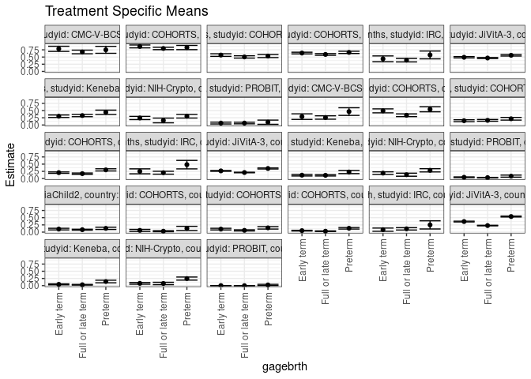

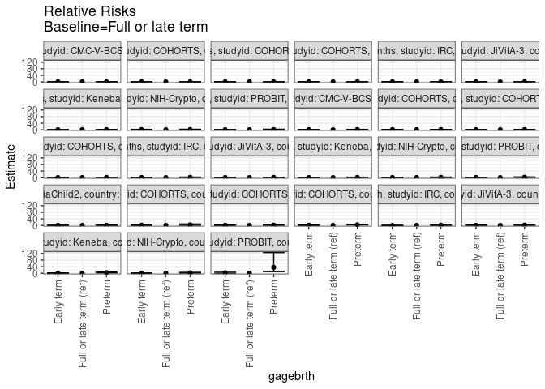

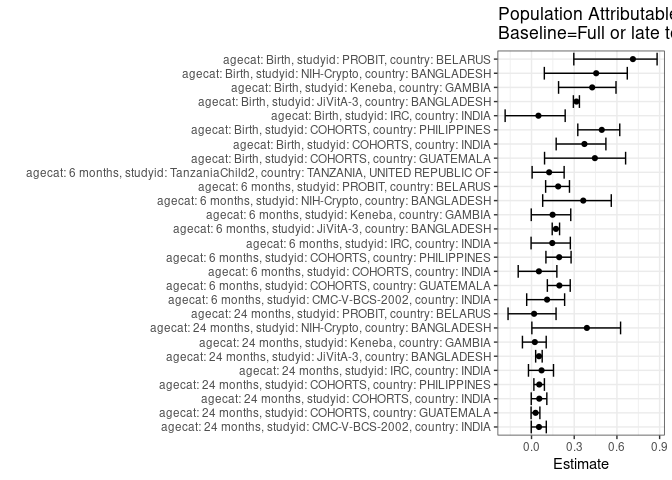

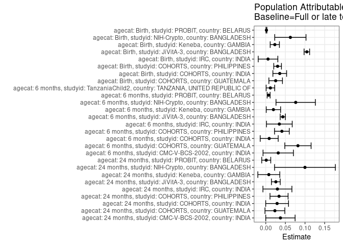

## Results Table

### Parameter: TSM

| agecat | studyid | country | intervention_level | baseline_level | estimate | ci_lower | ci_upper |
| --- | --- | --- | --- | --- | --- | --- | --- |
| Birth | COHORTS | GUATEMALA | Full or late term | NA | 0.0314825 | 0.0126800 | 0.0502850 |
| Birth | COHORTS | GUATEMALA | Preterm | NA | 0.1291997 | 0.0581635 | 0.2002358 |
| Birth | COHORTS | GUATEMALA | Early term | NA | 0.0593943 | 0.0242609 | 0.0945278 |
| Birth | COHORTS | INDIA | Full or late term | NA | 0.0602573 | 0.0407304 | 0.0797842 |
| Birth | COHORTS | INDIA | Preterm | NA | 0.1474371 | 0.1059534 | 0.1889208 |
| Birth | COHORTS | INDIA | Early term | NA | 0.1040460 | 0.0754638 | 0.1326281 |
| Birth | COHORTS | PHILIPPINES | Full or late term | NA | 0.0309857 | 0.0210288 | 0.0409426 |
| Birth | COHORTS | PHILIPPINES | Preterm | NA | 0.1322616 | 0.1057907 | 0.1587326 |
| Birth | COHORTS | PHILIPPINES | Early term | NA | 0.0509556 | 0.0386725 | 0.0632387 |
| Birth | IRC | INDIA | Full or late term | NA | 0.1134454 | 0.0730999 | 0.1537909 |
| Birth | IRC | INDIA | Preterm | NA | 0.2500000 | 0.1083597 | 0.3916403 |
| Birth | IRC | INDIA | Early term | NA | 0.0842105 | 0.0282919 | 0.1401292 |
| Birth | JiVitA-3 | BANGLADESH | Full or late term | NA | 0.2268961 | 0.2175846 | 0.2362075 |
| Birth | JiVitA-3 | BANGLADESH | Preterm | NA | 0.5402772 | 0.5238307 | 0.5567237 |
| Birth | JiVitA-3 | BANGLADESH | Early term | NA | 0.3665475 | 0.3528264 | 0.3802687 |
| Birth | Keneba | GAMBIA | Full or late term | NA | 0.0310547 | 0.0184865 | 0.0436229 |
| Birth | Keneba | GAMBIA | Preterm | NA | 0.1439135 | 0.0987041 | 0.1891229 |
| Birth | Keneba | GAMBIA | Early term | NA | 0.0451115 | 0.0274817 | 0.0627412 |
| Birth | NIH-Crypto | BANGLADESH | Full or late term | NA | 0.0752949 | 0.0341104 | 0.1164794 |
| Birth | NIH-Crypto | BANGLADESH | Preterm | NA | 0.2461997 | 0.1932572 | 0.2991423 |
| Birth | NIH-Crypto | BANGLADESH | Early term | NA | 0.0794606 | 0.0494462 | 0.1094750 |
| Birth | PROBIT | BELARUS | Full or late term | NA | 0.0007042 | -0.0002235 | 0.0016320 |
| Birth | PROBIT | BELARUS | Preterm | NA | 0.0254237 | 0.0044461 | 0.0464013 |
| Birth | PROBIT | BELARUS | Early term | NA | 0.0026894 | 0.0008212 | 0.0045577 |
| 6 months | CMC-V-BCS-2002 | INDIA | Full or late term | NA | 0.2592782 | 0.2000985 | 0.3184579 |
| 6 months | CMC-V-BCS-2002 | INDIA | Preterm | NA | 0.4650513 | 0.3318551 | 0.5982475 |
| 6 months | CMC-V-BCS-2002 | INDIA | Early term | NA | 0.2903768 | 0.1938795 | 0.3868742 |
| 6 months | COHORTS | GUATEMALA | Full or late term | NA | 0.3373589 | 0.2901690 | 0.3845487 |
| 6 months | COHORTS | GUATEMALA | Preterm | NA | 0.5450453 | 0.4575087 | 0.6325818 |
| 6 months | COHORTS | GUATEMALA | Early term | NA | 0.4907563 | 0.4222973 | 0.5592152 |

[output cut: 51 more lines]

### Parameter: E(Y)

| agecat | studyid | country | intervention_level | baseline_level | estimate | ci_lower | ci_upper |
| --- | --- | --- | --- | --- | --- | --- | --- |
| Birth | COHORTS | GUATEMALA | NA | NA | 0.0567261 | 0.0384591 | 0.0749931 |
| Birth | COHORTS | INDIA | NA | NA | 0.0959010 | 0.0798450 | 0.1119570 |
| Birth | COHORTS | PHILIPPINES | NA | NA | 0.0611772 | 0.0526341 | 0.0697204 |
| Birth | IRC | INDIA | NA | NA | 0.1192412 | 0.0861307 | 0.1523517 |
| Birth | JiVitA-3 | BANGLADESH | NA | NA | 0.3315456 | 0.3240495 | 0.3390416 |
| Birth | Keneba | GAMBIA | NA | NA | 0.0541254 | 0.0427281 | 0.0655227 |
| Birth | NIH-Crypto | BANGLADESH | NA | NA | 0.1379781 | 0.1129774 | 0.1629789 |
| Birth | PROBIT | BELARUS | NA | NA | 0.0024473 | 0.0007336 | 0.0041610 |
| 6 months | CMC-V-BCS-2002 | INDIA | NA | NA | 0.2910663 | 0.2432023 | 0.3389303 |
| 6 months | COHORTS | GUATEMALA | NA | NA | 0.4193548 | 0.3831093 | 0.4556004 |
| 6 months | COHORTS | INDIA | NA | NA | 0.1692073 | 0.1489117 | 0.1895030 |
| 6 months | COHORTS | PHILIPPINES | NA | NA | 0.2113882 | 0.1959475 | 0.2268289 |
| 6 months | IRC | INDIA | NA | NA | 0.2371134 | 0.1947393 | 0.2794875 |
| 6 months | JiVitA-3 | BANGLADESH | NA | NA | 0.2528420 | 0.2446204 | 0.2610636 |
| 6 months | Keneba | GAMBIA | NA | NA | 0.1317322 | 0.1138432 | 0.1496212 |
| 6 months | NIH-Crypto | BANGLADESH | NA | NA | 0.2097902 | 0.1799252 | 0.2396552 |
| 6 months | PROBIT | BELARUS | NA | NA | 0.0393401 | 0.0293640 | 0.0493162 |
| 6 months | TanzaniaChild2 | TANZANIA, UNITED REPUBLIC OF | NA | NA | 0.0956385 | 0.0824215 | 0.1088554 |
| 24 months | CMC-V-BCS-2002 | INDIA | NA | NA | 0.7134670 | 0.6659628 | 0.7609713 |
| 24 months | COHORTS | GUATEMALA | NA | NA | 0.8199697 | 0.7906576 | 0.8492819 |
| 24 months | COHORTS | INDIA | NA | NA | 0.5321101 | 0.5050591 | 0.5591611 |
| 24 months | COHORTS | PHILIPPINES | NA | NA | 0.6237624 | 0.6044733 | 0.6430515 |
| 24 months | IRC | INDIA | NA | NA | 0.4205128 | 0.3714576 | 0.4695680 |
| 24 months | JiVitA-3 | BANGLADESH | NA | NA | 0.4910997 | 0.4777434 | 0.5044561 |
| 24 months | Keneba | GAMBIA | NA | NA | 0.3356401 | 0.3084071 | 0.3628732 |
| 24 months | NIH-Crypto | BANGLADESH | NA | NA | 0.2568093 | 0.2190047 | 0.2946140 |
| 24 months | PROBIT | BELARUS | NA | NA | 0.0681537 | 0.0420376 | 0.0942697 |

### Parameter: RR

| agecat | studyid | country | intervention_level | baseline_level | estimate | ci_lower | ci_upper |
| --- | --- | --- | --- | --- | --- | --- | --- |
| Birth | COHORTS | GUATEMALA | Full or late term | Full or late term | 1.0000000 | 1.0000000 | 1.000000 |
| Birth | COHORTS | GUATEMALA | Preterm | Full or late term | 4.1038538 | 1.8204702 | 9.251245 |
| Birth | COHORTS | GUATEMALA | Early term | Full or late term | 1.8865801 | 0.8141233 | 4.371800 |
| Birth | COHORTS | INDIA | Full or late term | Full or late term | 1.0000000 | 1.0000000 | 1.000000 |
| Birth | COHORTS | INDIA | Preterm | Full or late term | 2.4467913 | 1.5934110 | 3.757215 |
| Birth | COHORTS | INDIA | Early term | Full or late term | 1.7266936 | 1.1293111 | 2.640079 |
| Birth | COHORTS | PHILIPPINES | Full or late term | Full or late term | 1.0000000 | 1.0000000 | 1.000000 |
| Birth | COHORTS | PHILIPPINES | Preterm | Full or late term | 4.2684728 | 2.9230055 | 6.233262 |
| Birth | COHORTS | PHILIPPINES | Early term | Full or late term | 1.6444882 | 1.1007828 | 2.456744 |
| Birth | IRC | INDIA | Full or late term | Full or late term | 1.0000000 | 1.0000000 | 1.000000 |
| Birth | IRC | INDIA | Preterm | Full or late term | 2.2037037 | 1.1288592 | 4.301963 |
| Birth | IRC | INDIA | Early term | Full or late term | 0.7423002 | 0.3494922 | 1.576600 |
| Birth | JiVitA-3 | BANGLADESH | Full or late term | Full or late term | 1.0000000 | 1.0000000 | 1.000000 |
| Birth | JiVitA-3 | BANGLADESH | Preterm | Full or late term | 2.3811661 | 2.2625400 | 2.506012 |
| Birth | JiVitA-3 | BANGLADESH | Early term | Full or late term | 1.6154866 | 1.5304426 | 1.705256 |
| Birth | Keneba | GAMBIA | Full or late term | Full or late term | 1.0000000 | 1.0000000 | 1.000000 |
| Birth | Keneba | GAMBIA | Preterm | Full or late term | 4.6341898 | 2.7766942 | 7.734275 |
| Birth | Keneba | GAMBIA | Early term | Full or late term | 1.4526443 | 0.8274012 | 2.550365 |
| Birth | NIH-Crypto | BANGLADESH | Full or late term | Full or late term | 1.0000000 | 1.0000000 | 1.000000 |
| Birth | NIH-Crypto | BANGLADESH | Preterm | Full or late term | 3.2698066 | 1.8163018 | 5.886486 |
| Birth | NIH-Crypto | BANGLADESH | Early term | Full or late term | 1.0553257 | 0.5427165 | 2.052107 |
| Birth | PROBIT | BELARUS | Full or late term | Full or late term | 1.0000000 | 1.0000000 | 1.000000 |
| Birth | PROBIT | BELARUS | Preterm | Full or late term | 36.1016949 | 10.3744573 | 125.628969 |
| Birth | PROBIT | BELARUS | Early term | Full or late term | 3.8190160 | 1.3496706 | 10.806254 |
| 6 months | CMC-V-BCS-2002 | INDIA | Full or late term | Full or late term | 1.0000000 | 1.0000000 | 1.000000 |
| 6 months | CMC-V-BCS-2002 | INDIA | Preterm | Full or late term | 1.7936381 | 1.2450404 | 2.583962 |
| 6 months | CMC-V-BCS-2002 | INDIA | Early term | Full or late term | 1.1199431 | 0.7486707 | 1.675333 |
| 6 months | COHORTS | GUATEMALA | Full or late term | Full or late term | 1.0000000 | 1.0000000 | 1.000000 |
| 6 months | COHORTS | GUATEMALA | Preterm | Full or late term | 1.6156247 | 1.3059356 | 1.998753 |
| 6 months | COHORTS | GUATEMALA | Early term | Full or late term | 1.4547010 | 1.1937260 | 1.772731 |

[output cut: 51 more lines]

### Parameter: PAR

| agecat | studyid | country | intervention_level | baseline_level | estimate | ci_lower | ci_upper |
| --- | --- | --- | --- | --- | --- | --- | --- |
| Birth | COHORTS | GUATEMALA | Full or late term | NA | 0.0252436 | 0.0079572 | 0.0425299 |
| Birth | COHORTS | INDIA | Full or late term | NA | 0.0356437 | 0.0181560 | 0.0531313 |
| Birth | COHORTS | PHILIPPINES | Full or late term | NA | 0.0301915 | 0.0204151 | 0.0399680 |
| Birth | IRC | INDIA | Full or late term | NA | 0.0057958 | -0.0191902 | 0.0307818 |
| Birth | JiVitA-3 | BANGLADESH | Full or late term | NA | 0.1046495 | 0.0975785 | 0.1117205 |
| Birth | Keneba | GAMBIA | Full or late term | NA | 0.0230707 | 0.0113297 | 0.0348117 |
| Birth | NIH-Crypto | BANGLADESH | Full or late term | NA | 0.0626832 | 0.0228168 | 0.1025497 |
| Birth | PROBIT | BELARUS | Full or late term | NA | 0.0017431 | 0.0005871 | 0.0028990 |
| 6 months | CMC-V-BCS-2002 | INDIA | Full or late term | NA | 0.0317881 | -0.0069081 | 0.0704843 |
| 6 months | COHORTS | GUATEMALA | Full or late term | NA | 0.0819960 | 0.0485030 | 0.1154889 |
| 6 months | COHORTS | INDIA | Full or late term | NA | 0.0087778 | -0.0141460 | 0.0317015 |
| 6 months | COHORTS | PHILIPPINES | Full or late term | NA | 0.0410880 | 0.0222956 | 0.0598804 |
| 6 months | IRC | INDIA | Full or late term | NA | 0.0345968 | 0.0018001 | 0.0673935 |
| 6 months | JiVitA-3 | BANGLADESH | Full or late term | NA | 0.0433872 | 0.0368137 | 0.0499607 |
| 6 months | Keneba | GAMBIA | Full or late term | NA | 0.0195104 | 0.0011857 | 0.0378351 |
| 6 months | NIH-Crypto | BANGLADESH | Full or late term | NA | 0.0762472 | 0.0260647 | 0.1264296 |
| 6 months | PROBIT | BELARUS | Full or late term | NA | 0.0073638 | 0.0035967 | 0.0111308 |
| 6 months | TanzaniaChild2 | TANZANIA, UNITED REPUBLIC OF | Full or late term | NA | 0.0118441 | 0.0009988 | 0.0226894 |
| 24 months | CMC-V-BCS-2002 | INDIA | Full or late term | NA | 0.0373683 | -0.0000174 | 0.0747541 |
| 24 months | COHORTS | GUATEMALA | Full or late term | NA | 0.0232435 | -0.0019993 | 0.0484863 |
| 24 months | COHORTS | INDIA | Full or late term | NA | 0.0289307 | -0.0001231 | 0.0579845 |
| 24 months | COHORTS | PHILIPPINES | Full or late term | NA | 0.0338421 | 0.0108109 | 0.0568734 |
| 24 months | IRC | INDIA | Full or late term | NA | 0.0296968 | -0.0071975 | 0.0665911 |
| 24 months | JiVitA-3 | BANGLADESH | Full or late term | NA | 0.0256679 | 0.0144809 | 0.0368549 |
| 24 months | Keneba | GAMBIA | Full or late term | NA | 0.0077950 | -0.0201893 | 0.0357793 |
| 24 months | NIH-Crypto | BANGLADESH | Full or late term | NA | 0.0998682 | 0.0223582 | 0.1773782 |
| 24 months | PROBIT | BELARUS | Full or late term | NA | 0.0012353 | -0.0102494 | 0.0127200 |

### Parameter: PAF

| agecat | studyid | country | intervention_level | baseline_level | estimate | ci_lower | ci_upper |
| --- | --- | --- | --- | --- | --- | --- | --- |
| Birth | COHORTS | GUATEMALA | Full or late term | NA | 0.4450081 | 0.0914890 | 0.6609661 |
| Birth | COHORTS | INDIA | Full or late term | NA | 0.3716715 | 0.1731678 | 0.5225190 |
| Birth | COHORTS | PHILIPPINES | Full or late term | NA | 0.4935093 | 0.3251275 | 0.6198797 |
| Birth | IRC | INDIA | Full or late term | NA | 0.0486058 | -0.1854004 | 0.2364176 |
| Birth | JiVitA-3 | BANGLADESH | Full or late term | NA | 0.3156414 | 0.2941001 | 0.3365253 |
| Birth | Keneba | GAMBIA | Full or late term | NA | 0.4262450 | 0.1900254 | 0.5935739 |
| Birth | NIH-Crypto | BANGLADESH | Full or late term | NA | 0.4542984 | 0.0899410 | 0.6727792 |
| Birth | PROBIT | BELARUS | Full or late term | NA | 0.7122411 | 0.2970627 | 0.8822012 |
| 6 months | CMC-V-BCS-2002 | INDIA | Full or late term | NA | 0.1092125 | -0.0339650 | 0.2325635 |
| 6 months | COHORTS | GUATEMALA | Full or late term | NA | 0.1955289 | 0.1111918 | 0.2718634 |
| 6 months | COHORTS | INDIA | Full or late term | NA | 0.0518758 | -0.0936125 | 0.1780092 |
| 6 months | COHORTS | PHILIPPINES | Full or late term | NA | 0.1943722 | 0.1011716 | 0.2779087 |
| 6 months | IRC | INDIA | Full or late term | NA | 0.1459081 | -0.0030610 | 0.2727531 |
| 6 months | JiVitA-3 | BANGLADESH | Full or late term | NA | 0.1715980 | 0.1453059 | 0.1970814 |
| 6 months | Keneba | GAMBIA | Full or late term | NA | 0.1481068 | -0.0018313 | 0.2756046 |
| 6 months | NIH-Crypto | BANGLADESH | Full or late term | NA | 0.3634448 | 0.0784459 | 0.5603052 |
| 6 months | PROBIT | BELARUS | Full or late term | NA | 0.1871821 | 0.0991560 | 0.2666066 |
| 6 months | TanzaniaChild2 | TANZANIA, UNITED REPUBLIC OF | Full or late term | NA | 0.1238423 | 0.0041301 | 0.2291642 |
| 24 months | CMC-V-BCS-2002 | INDIA | Full or late term | NA | 0.0523757 | -0.0019680 | 0.1037719 |
| 24 months | COHORTS | GUATEMALA | Full or late term | NA | 0.0283468 | -0.0030663 | 0.0587760 |
| 24 months | COHORTS | INDIA | Full or late term | NA | 0.0543698 | -0.0019781 | 0.1075490 |
| 24 months | COHORTS | PHILIPPINES | Full or late term | NA | 0.0542549 | 0.0165160 | 0.0905456 |
| 24 months | IRC | INDIA | Full or late term | NA | 0.0706204 | -0.0214482 | 0.1543904 |
| 24 months | JiVitA-3 | BANGLADESH | Full or late term | NA | 0.0522662 | 0.0290687 | 0.0749095 |
| 24 months | Keneba | GAMBIA | Full or late term | NA | 0.0232243 | -0.0638214 | 0.1031476 |
| 24 months | NIH-Crypto | BANGLADESH | Full or late term | NA | 0.3888807 | 0.0024078 | 0.6256319 |
| 24 months | PROBIT | BELARUS | Full or late term | NA | 0.0181253 | -0.1648639 | 0.1723687 |